# My visual data story

## Introduction

This visual data story is based on observational data about students learning the Python programming language. We recorded the time spent learning Python, the basics of English, and their subjective ratings of the difficulty of Python for students of different majors.

The following chart shows the relationship between a student’s background and their learning experience and helps us gain a deeper understanding of the factors that influence the difficulty of learning Python.

## The number of students in different majors

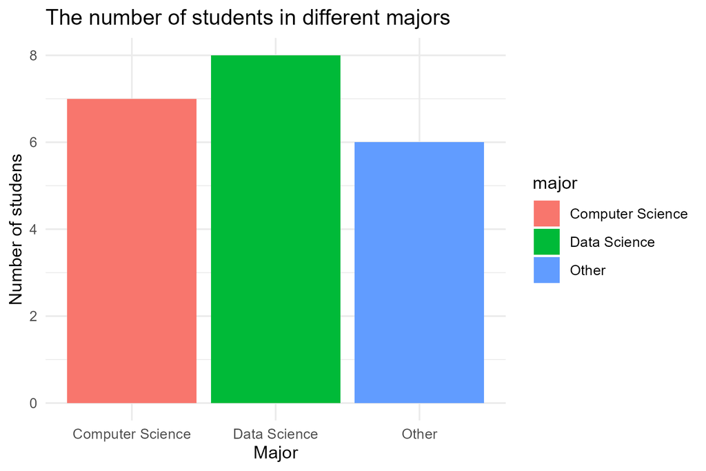

Students from different majors participated in this data recording. From the chart above, we can see the distribution of major majors that participated in the survey, such as Data Science and Computer Science.

## Distribution of time spent on learning Python per day

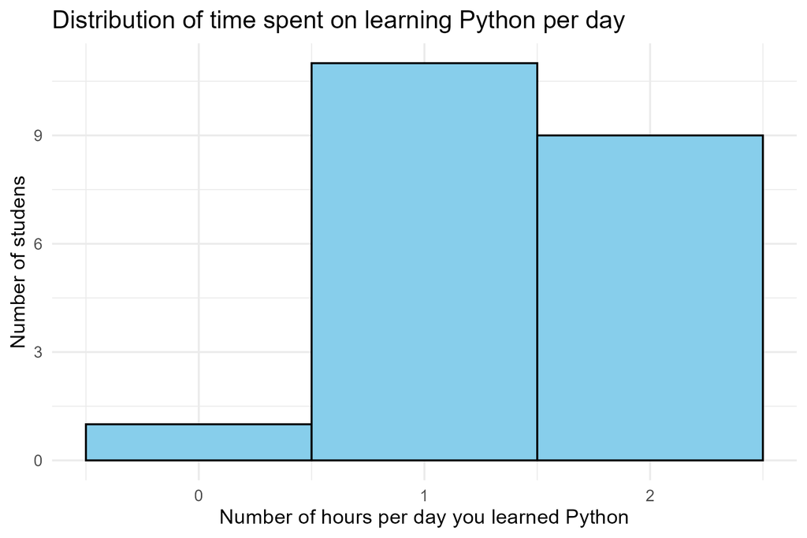

## Distribution of Python difficulty ratings by students of different majors

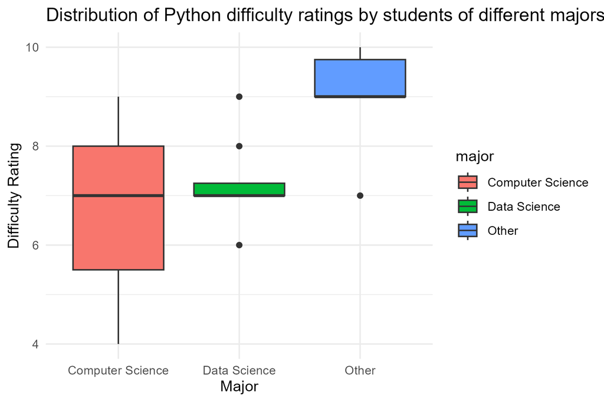

The box plot shows how difficult Python was rated by students of different majors (on a scale of 1 to 10, with higher scores indicating more difficult). We can observe that the ratings of certain majors are more concentrated, possibly reflecting the influence of course design or background knowledge on the learning experience

## Conclusion

From the above chart, we can get a initial understanding:

- Most students spend 1-2 hours a day learning Python.
- Students of different majors have different perceptions of learning difficulty;
- Further research can include variables such as English years into the investigation to explore their relationship with learning outcomes.

Thank you for reading my visual data story!!!